# Análisis integral de registros de biodiversidad GBIF

Región Colón–Cocos | Completitud, depuración y análisis espacio-temporal

## 1. Objetivo y alcance

Este informe integra dos procedimientos aplicados a la descarga original de GBIF: (1) evaluación de completitud, cobertura y composición de registros, y (2) preparación de un subconjunto con información temporal para su análisis anual, mensual y espacial. El archivo Excel original **no se modifica**.

**Criterio de inclusión temporal.** De los 21.593 registros originales, el segundo procedimiento conservó 15.006 (69,5 %) al exigir que el registro tuviera una fecha original `eventDate` **o** una fecha completa reconstruible a partir de `year`, `month` y `day`. Los 6.587 restantes (30,5 %) carecían de ambas. La condición se reproduce en este informe para obtener el mismo subconjunto; no supone una selección por calidad taxonómica ni por tipo de registro. La completitud global se calcula sobre toda la base original.

**Precaución:** un registro con año conocido, pero sin mes o día, puede quedar excluido de este subconjunto si `eventDate` también está ausente. Para conservar la información temporal disponible se crea `fecha_analisis`, que prioriza la fecha reconstruida y utiliza la fecha original como alternativa. Los resultados históricos describen *frecuencia de registros GBIF*, no tendencias de abundancia ni cambios demostrados de biodiversidad.

## 2. Paquetes y carga de la base original

**Código**

```r
library(readxl)
library(dplyr)
library(tidyr)
library(ggplot2)
library(stringr)
library(lubridate)
library(sf)
library(rnaturalearth)
library(rnaturalearthdata)

ruta_archivo <- file.path(
  "/Users/anita/Documents/Documentos/curso R/Proyecto_final_Hackaton_2026",
  "data",
  "GBIF_Colon_Coco_2026_TableToExcel original descargada de Gbif.xlsx"
)
cat("Directorio de Quarto:", getwd(), "\n")
```

```
Directorio de Quarto: /Users/anita/Documents/Documentos/curso R/Proyecto_final_Hackaton_2026
```

**Código**

```r
cat("¿Existe el Excel?:", file.exists(ruta_archivo), "\n")
```

```
¿Existe el Excel?: TRUE
```

**Código**

```r
if (!file.exists(ruta_archivo)) {
  stop("No se encontró el archivo: ", ruta_archivo,
       ". Verifica la carpeta 'data' dentro del proyecto.")
}

datos_gbif <- read_excel(ruta_archivo)
n_filas <- nrow(datos_gbif)
n_cols <- ncol(datos_gbif)
cat("Registros originales:", n_filas, "\n")
```

```
Registros originales: 21593
```

**Código**

```r
cat("Variables originales:", n_cols, "\n")
```

```
Variables originales: 233
```

**Código**

```r
# Se mantienen los datos crudos separados de sus derivados.
```

## 3. Completitud de las variables

Se consideran faltantes tanto los `NA` como los textos vacíos o formados únicamente por espacios. Esta evaluación se realiza sobre **todos los registros originales**.

**Código**

```r
base_completitud <- datos_gbif %>%
  mutate(across(where(is.character), ~ na_if(trimws(.x), "")))

tabla_completitud <- base_completitud %>%
  summarise(across(everything(), ~ sum(is.na(.x)))) %>%
  pivot_longer(everything(), names_to = "variable", values_to = "n_faltantes") %>%
  mutate(
    n_completos = n_filas - n_faltantes,
    pct_faltantes = round(100 * n_faltantes / n_filas, 2),
    pct_completitud = round(100 * n_completos / n_filas, 2)
  ) %>%
  arrange(desc(pct_completitud), variable)

resumen_completitud <- tabla_completitud %>%
  summarise(
    total_variables = n(),
    vars_100_completas = sum(n_faltantes == 0),
    vars_mayor_igual_80_pct = sum(pct_completitud >= 80),
    vars_menor_50_pct = sum(pct_completitud < 50),
    vars_totalmente_vacias = sum(n_completos == 0)
  )
print(resumen_completitud)
```

```
# A tibble: 1 × 5
  total_variables vars_100_completas vars_mayor_igual_80_pct vars_menor_50_pct
            <int>              <int>                   <int>             <int>
1             233                 23                      41               176
# ℹ 1 more variable: vars_totalmente_vacias <int>
```

**Código**

```r
print(head(tabla_completitud, 25), n = 25)
```

```
# A tibble: 25 × 5
   variable               n_faltantes n_completos pct_faltantes pct_completitud
   <chr>                        <int>       <int>         <dbl>           <dbl>
 1 OBJECTID                         0       21593          0              100
 2 acceptedScientificName           0       21593          0              100
 3 acceptedTaxonKey                 0       21593          0              100
 4 basisOfRecord                    0       21593          0              100
 5 datasetKey                       0       21593          0              100
 6 decimalLatitude                  0       21593          0              100
 7 decimalLongitude                 0       21593          0              100
 8 gbifID                           0       21593          0              100
 9 hasCoordinate                    0       21593          0              100
10 hasGeospatialIssues              0       21593          0              100
11 isSequenced                      0       21593          0              100
12 kingdom                          0       21593          0              100
13 kingdomKey                       0       21593          0              100
14 lastCrawled                      0       21593          0              100
15 lastInterpreted                  0       21593          0              100
16 license                          0       21593          0              100
17 occurrenceStatus                 0       21593          0              100
18 protocol                         0       21593          0              100
19 publishedByGbifRegion            1       21592          0              100
20 publisher                        0       21593          0              100
21 publishingCountry                0       21593          0              100
22 scientificName                   0       21593          0              100
23 taxonKey                         0       21593          0              100
24 taxonRank                        0       21593          0              100
25 verbatimScientificName           4       21589          0.02           100.0
```

### Variables relevantes para biodiversidad

**Código**

```r
vars_clave_gbif <- c(
  "gbifID", "scientificName", "species", "acceptedScientificName",
  "taxonRank", "taxonomicStatus", "kingdom", "phylum", "class",
  "order", "order_", "family", "genus", "decimalLatitude", "decimalLongitude",
  "coordinateUncertaintyInMeters", "countryCode", "locality", "stateProvince",
  "depth", "elevation", "eventDate", "year", "month", "day",
  "basisOfRecord", "occurrenceStatus", "individualCount",
  "institutionCode", "datasetName", "issue"
)
completitud_clave <- tabla_completitud %>% filter(variable %in% vars_clave_gbif)

print(completitud_clave, n = Inf)
```

```
# A tibble: 30 × 5
   variable                n_faltantes n_completos pct_faltantes pct_completitud
   <chr>                         <int>       <int>         <dbl>           <dbl>
 1 acceptedScientificName            0       21593          0             100
 2 basisOfRecord                     0       21593          0             100
 3 decimalLatitude                   0       21593          0             100
 4 decimalLongitude                  0       21593          0             100
 5 gbifID                            0       21593          0             100
 6 kingdom                           0       21593          0             100
 7 occurrenceStatus                  0       21593          0             100
 8 scientificName                    0       21593          0             100
 9 taxonRank                         0       21593          0             100
10 institutionCode                 311       21282          1.44           98.6
11 phylum                          867       20726          4.02           96.0
12 taxonomicStatus                 867       20726          4.02           96.0
```

[output cut: 18 more lines]

**Código**

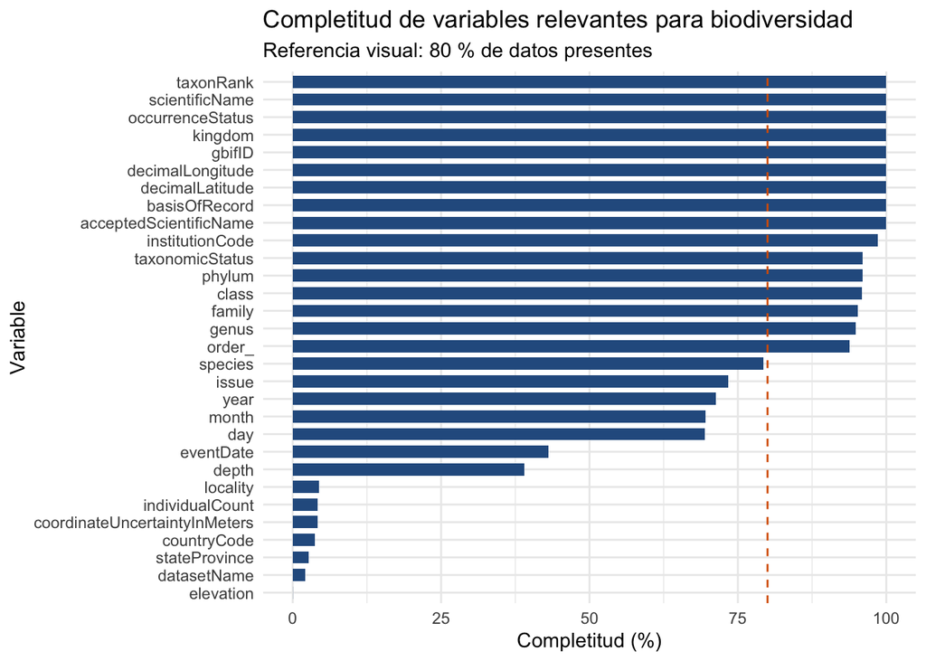

```r
ggplot(completitud_clave, aes(x = reorder(variable, pct_completitud), y = pct_completitud)) +
  geom_col(fill = "#2b5c8f", width = 0.7) +
  geom_hline(yintercept = 80, linetype = "dashed", color = "#d95f02") +
  coord_flip() +
  labs(
    title = "Completitud de variables relevantes para biodiversidad",
    subtitle = "Referencia visual: 80 % de datos presentes",
    x = "Variable", y = "Completitud (%)"
  ) +
  theme_minimal()
```

## 4. Caracterización de la base original

### Cobertura geográfica

**Código**

```r
resumen_espacial_original <- datos_gbif %>%
  summarise(
    registros_totales = n(),
    con_coordenadas = sum(!is.na(decimalLatitude) & !is.na(decimalLongitude)),
    coordenadas_rango_valido = sum(
      !is.na(decimalLatitude) & !is.na(decimalLongitude) &
      between(decimalLatitude, -90, 90) & between(decimalLongitude, -180, 180)
    ),
    lat_min = min(decimalLatitude, na.rm = TRUE),
    lat_max = max(decimalLatitude, na.rm = TRUE),
    lon_min = min(decimalLongitude, na.rm = TRUE),
    lon_max = max(decimalLongitude, na.rm = TRUE)
  )
print(resumen_espacial_original)
```

```
# A tibble: 1 × 7
  registros_totales con_coordenadas coordenadas_rango_valido lat_min lat_max
              <int>           <int>                    <int>   <dbl>   <dbl>
1             21593           21593                    21593 -0.0746    6.07
# ℹ 2 more variables: lon_min <dbl>, lon_max <dbl>
```

Que las coordenadas se encuentren dentro de rangos numéricos válidos no demuestra que todas correspondan a la región de estudio o que sean exactas; eso requiere controles geográficos adicionales.

### Cobertura temporal original

**Código**

```r
resumen_temporal_original <- datos_gbif %>%
  summarise(
    con_anio = sum(!is.na(year)),
    sin_anio = sum(is.na(year)),
    pct_con_anio = round(100 * con_anio / n(), 2),
    anio_inicio = min(year, na.rm = TRUE),
    anio_fin = max(year, na.rm = TRUE)
  )
print(resumen_temporal_original)
```

```
# A tibble: 1 × 5
  con_anio sin_anio pct_con_anio anio_inicio anio_fin
     <int>    <int>        <dbl>       <dbl>    <dbl>
1    15390     6203         71.3        1860     2023
```

### Resumen taxonómico preliminar

**Código**

```r
datos_biodiv <- datos_gbif %>% select(any_of(vars_clave_gbif))
resumen_taxonomico <- datos_biodiv %>%
  summarise(
    total_registros = n(),
    registros_con_species = sum(!is.na(species) & trimws(species) != ""),
    nombres_distintos_species = n_distinct(species[!is.na(species) & trimws(species) != ""]),
    generos_distintos = n_distinct(genus[!is.na(genus) & trimws(genus) != ""]),
    familias_distintas = n_distinct(family[!is.na(family) & trimws(family) != ""]),
    filos_distintos = n_distinct(phylum[!is.na(phylum) & trimws(phylum) != ""])
  )
print(resumen_taxonomico)
```

```
# A tibble: 1 × 6
  total_registros registros_con_species nombres_distintos_sp…¹ generos_distintos
            <int>                 <int>                  <int>             <int>
1           21593                 17132                    833               613
# ℹ abbreviated name: ¹nombres_distintos_species
# ℹ 2 more variables: familias_distintas <int>, filos_distintos <int>
```

**Código**

```r
if ("basisOfRecord" %in% names(datos_biodiv)) {
  tipos_registro <- datos_biodiv %>%
    count(basisOfRecord, sort = TRUE) %>%
    mutate(pct = round(100 * n / sum(n), 2))
  print(tipos_registro, n = Inf)
}
```

```
# A tibble: 7 × 3
  basisOfRecord           n   pct
  <chr>               <int> <dbl>
1 OCCURRENCE           8213 38.0
2 FOSSIL_SPECIMEN      6046 28
3 HUMAN_OBSERVATION    5649 26.2
4 PRESERVED_SPECIMEN   1498  6.94
5 MACHINE_OBSERVATION   172  0.8
6 MATERIAL_SAMPLE        12  0.06
7 MATERIAL_CITATION       3  0.01
```

Estos conteos de nombres reflejan la taxonomía tal como figura en la descarga original; no sustituyen una validación nomenclatural ni el tratamiento de sinonimias. Los registros fósiles deben distinguirse de observaciones de organismos actuales cuando la interpretación científica lo requiera.

## 5. Depuración y selección de 15.006 registros

### Columnas completamente vacías

**Código**

```r
columnas_vacias <- tabla_completitud %>%
  filter(n_completos == 0) %>%
  pull(variable)
cat("Columnas totalmente vacías:", length(columnas_vacias), "\n")
```

```
Columnas totalmente vacías: 68
```

**Código**

```r
datos_gbif_clean <- datos_gbif %>% select(-any_of(columnas_vacias))
cat("Columnas conservadas:", ncol(datos_gbif_clean), "\n")
```

```
Columnas conservadas: 165
```

### Fechas y regla de inclusión

**Código**

```r
# Se conserva el procedimiento de selección utilizado en el segundo script.
datos_gbif_final <- datos_gbif_clean %>%
  select(OBJECTID, eventDate, year, month, day,
         decimalLatitude, decimalLongitude, scientificName) %>%
  rename(id = OBJECTID,
         latitud = decimalLatitude,
         longitud = decimalLongitude) %>%
  mutate(
    eventDate_new = lubridate::make_date(
      year = as.integer(year),
      month = as.integer(month),
      day = as.integer(day)
    )
  )

# Evaluación de la condición de exclusión, ANTES de filtrar.
filas_sin_ambas_fechas <- datos_gbif_final %>%
  filter(is.na(eventDate_new) & is.na(eventDate))

resumen_filtro <- tibble(
  categoria = c("Registros originales", "Sin ambas fechas", "Registros conservados"),
  registros = c(nrow(datos_gbif_final),
                nrow(filas_sin_ambas_fechas),
                nrow(datos_gbif_final) - nrow(filas_sin_ambas_fechas))
) %>% mutate(pct_original = round(100 * registros / n_filas, 2))
print(resumen_filtro)
```

```
# A tibble: 3 × 3
  categoria             registros pct_original
  <chr>                     <int>        <dbl>
1 Registros originales      21593        100
2 Sin ambas fechas           6587         30.5
3 Registros conservados     15006         69.5
```

**Código**

```r
# Filtro exactamente equivalente al del segundo script.
datos_gbif_final <- datos_gbif_final %>%
  filter(!(is.na(eventDate_new) & is.na(eventDate))) %>%
  mutate(
    fecha_analisis = coalesce(as.Date(eventDate_new), as.Date(eventDate))
  )

# Para detectar cambios inesperados en esta versión de la base.
if (n_filas == 21593 && nrow(datos_gbif_final) != 15006) {
  warning("El filtro no produjo 15.006 registros. Revisa la importación o las fechas.")
}

resumen_fechas <- datos_gbif_final %>%
  summarise(
    registros_conservados = n(),
    fecha_reconstruida = sum(!is.na(eventDate_new)),
    fecha_original = sum(!is.na(eventDate)),
    fecha_final_disponible = sum(!is.na(fecha_analisis)),
    fecha_final_faltante = sum(is.na(fecha_analisis))
  )
print(resumen_fechas)
```

```
# A tibble: 1 × 5
  registros_conservados fecha_reconstruida fecha_original fecha_final_disponible
                  <int>              <int>          <int>                  <int>
1                 15006              15006           9307                  15006
# ℹ 1 more variable: fecha_final_faltante <int>
```

La fecha `fecha_analisis` utiliza `eventDate_new` cuando se puede reconstruir con día, mes y año; de lo contrario, utiliza `eventDate` si está disponible. Esta regla evita dejar fechas vacías por haber descartado la columna original después del filtrado. No implica que todas las fechas originales tengan igual precisión.

### Tabla preparada para análisis y exportación

**Código**

```r
datos_gbif_analisis <- datos_gbif_final %>%
  transmute(
    id,
    eventDate = fecha_analisis,
    longitud,
    latitud,
    scientificName
  )

cat("Dimensiones de la base de análisis: ",
    nrow(datos_gbif_analisis), " filas x ",
    ncol(datos_gbif_analisis), " columnas\n", sep = "")
```

```
Dimensiones de la base de análisis: 15006 filas x 5 columnas
```

**Código**

```r
print(head(datos_gbif_analisis, 15), n = 15)
```

```
# A tibble: 15 × 5
      id eventDate  longitud latitud scientificName
   <dbl> <date>        <dbl>   <dbl> <chr>
 1     2 2016-10-15    -94.3   4.60  Rhaucus marmoratus (Roewer, 1912)
 2     3 1979-07-01    -96.7   3.61  Solenopsis Westwood, 1840
 3     4 1999-09-24    -94.9   3.38  Cetacea Brisson, 1762
 4     5 1999-10-11    -91.1   5.4   Cetacea Brisson, 1762
 5     6 1999-10-11    -91.1   5.4   Grampus griseus (G. Cuvier, 1812)
 6     7 1999-10-11    -91.1   5.43  Orcinus orca (Linnaeus, 1758)
 7     8 1952-06-21    -97.3   4.07  Thysanopoda egregia Hansen, 1905
 8     9 1985-08-31    -97.0   0.504 Parus bicolor Linnaeus, 1766
 9    10 1961-10-26    -95.8   0.87  Lycaea pulex Marion, 1874
10    13 1952-06-21    -97.2   4     Paradinonemertes macrostomum Coe, 1954
11    14 1997-05-03    -95.6   3.43  Carex shinnersii P.Rothr. & Reznicek
12    15 1984-09-02    -96.0   0.493 Parus bicolor Linnaeus, 1766
13    16 1952-06-21    -97.2   4     Plotonemertes adhaerens Brinkmann, 1917
14    17 1984-09-15    -97.0   0.505 Parus bicolor Linnaeus, 1766
15    18 1967-09-18    -92.0   5.67  Primno Guérin-Méneville, 1836
```

**Código**

```r
# Los archivos derivados se guardan aparte y NO sobrescriben el Excel original.
dir.create("resultados_GBIF", showWarnings = FALSE, recursive = TRUE)
write.csv(datos_gbif_analisis,
          "resultados_GBIF/datos_gbif_analisis_integral.csv",
          row.names = FALSE, na = "")
write.csv(tabla_completitud,
          "resultados_GBIF/tabla_completitud_integral.csv",
          row.names = FALSE, na = "")
```

## 6. Distribución temporal del subconjunto

### Registros por año y mes

**Código**

```r
resumen_anual_mensual <- datos_gbif_final %>%
  group_by(year, month) %>%
  summarise(numero_registros = n(), .groups = "drop") %>%
  arrange(year, month)

print(resumen_anual_mensual, n = Inf)
```

```
# A tibble: 341 × 3
     year month numero_registros
    <dbl> <dbl>            <int>
  1  1860     7                1
  2  1861     5                1
  3  1862     7                1
  4  1865     7                1
  5  1870    10                1
  6  1873    12                1
  7  1874     1                1
  8  1875     2                1
  9  1875    12                1
 10  1876     1                2
 11  1876     6                1
 12  1876    12                1
```

[output cut: 329 more lines]

**Código**

```r
# El criterio del script original era > 10 (es decir, al menos 11 registros).
meses_mas_10 <- resumen_anual_mensual %>%
  filter(numero_registros > 10) %>%
  arrange(year, month)
cat("Combinaciones año-mes con más de 10 registros:", nrow(meses_mas_10), "\n")
```

```
Combinaciones año-mes con más de 10 registros: 41
```

**Código**

```r
print(meses_mas_10, n = Inf)
```

```
# A tibble: 41 × 3
    year month numero_registros
   <dbl> <dbl>            <int>
 1  1896     6               13
 2  1914     5               11
 3  1928     8               39
 4  1949     6               11
 5  1949     7               17
 6  1951     7               13
 7  1952     6               65
 8  1952     7               25
 9  1967     2               18
10  1967     7               13
11  1967     9               26
12  1968     4               13
```

[output cut: 29 more lines]

Las filas con `month = NA` permanecen en este resumen porque pueden tener un año válido. Para los gráficos temporales se excluyen únicamente las fechas o componentes faltantes que impiden representar el eje correspondiente.

### Distribución histórica en intervalos de cinco años

**Código**

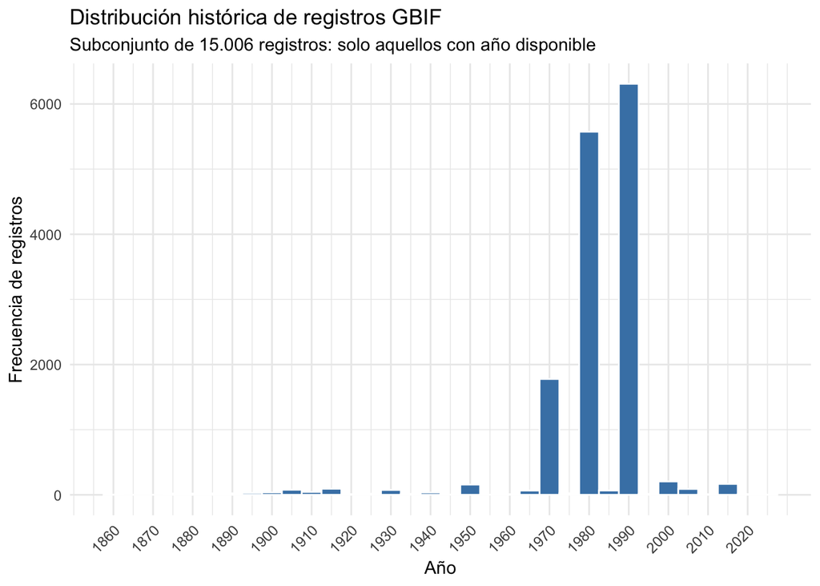

```r
ggplot(datos_gbif_final %>% filter(!is.na(year)), aes(x = year)) +
  geom_histogram(
    binwidth = 5,
    fill = "steelblue",
    color = "white"
  ) +
  scale_x_continuous(
    breaks = seq(1860, 2025, by = 10)
  ) +
  labs(
    title = "Distribución histórica de registros GBIF",
    subtitle = "Subconjunto de 15.006 registros: solo aquellos con año disponible",
    x = "Año",
    y = "Frecuencia de registros"
  ) +
  theme_minimal() +
  theme(
    axis.text.x = element_text(
      angle = 45,
      hjust = 1,
      size = 9
    )
  )
```

### Años con mayor número de registros GBIF

**Código**

```r
ranking_anual <- datos_gbif_final %>%
  filter(!is.na(year)) %>%
  count(year, name = "numero_registros") %>%
  arrange(desc(numero_registros))

# Mostrar todos los años ordenados
print(ranking_anual, n = Inf)
```

```
# A tibble: 125 × 2
     year numero_registros
    <dbl>            <int>
  1  1991             6027
  2  1979             5564
  3  1970             1716
  4  1992              169
  5  1998              140
  6  1952              106
  7  2016               71
  8  2006               65
  9  2015               65
 10  1967               59
 11  1989               56
 12  2000               53
```

[output cut: 113 more lines]

### Diez años con mayor cantidad de ocurrencias

**Código**

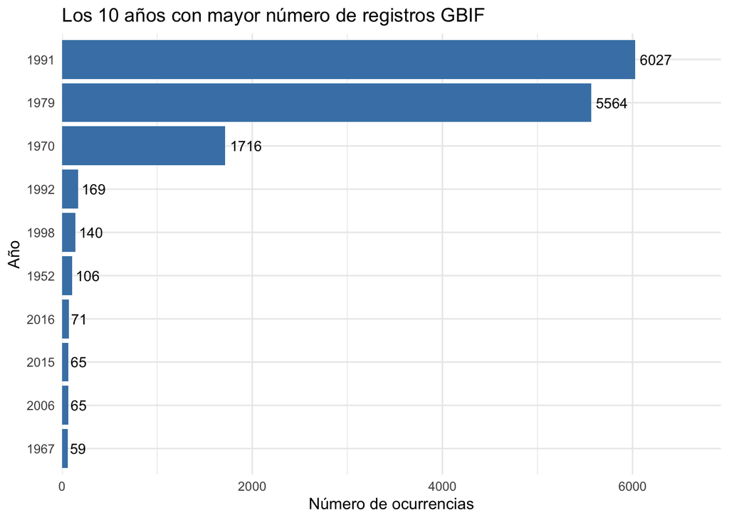

```r
ranking_anual %>%
  slice_max(numero_registros, n = 10, with_ties = FALSE) %>%
  ggplot(aes(
    x = reorder(factor(year), numero_registros),
    y = numero_registros
  )) +
  geom_col(fill = "steelblue") +
  geom_text(aes(label = numero_registros),
            hjust = -0.15, size = 3.5) +
  coord_flip() +
  scale_y_continuous(expand = expansion(mult = c(0, 0.15))) +
  labs(
    title = "Los 10 años con mayor número de registros GBIF",
    x = "Año",
    y = "Número de ocurrencias"
  ) +
  theme_minimal()
```

### Distribución mensual

**Código**

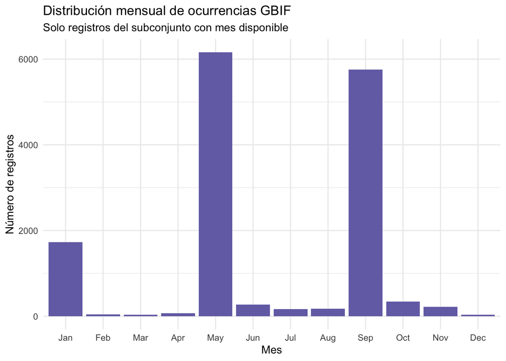

```r
datos_gbif_final %>%
  filter(!is.na(month), between(month, 1, 12)) %>%
  count(month) %>%
  ggplot(aes(x = factor(month, levels = 1:12, labels = month.abb), y = n)) +
  geom_col(fill = "#7570b3") +
  labs(title = "Distribución mensual de ocurrencias GBIF",
       subtitle = "Solo registros del subconjunto con mes disponible",
       x = "Mes", y = "Número de registros") +
  theme_minimal()
```

## 7. Distribución geográfica del subconjunto

### Comprobación de coordenadas

**Código**

```r
datos_mapa <- datos_gbif_final %>%
  filter(!is.na(longitud), !is.na(latitud),
         between(longitud, -180, 180),
         between(latitud, -90, 90))
cat("Registros del subconjunto con coordenadas en rangos válidos:",
    nrow(datos_mapa), "\n")
```

```
Registros del subconjunto con coordenadas en rangos válidos: 15006
```

### Mapa de ocurrencias en la región Colón–Cocos

**Código**

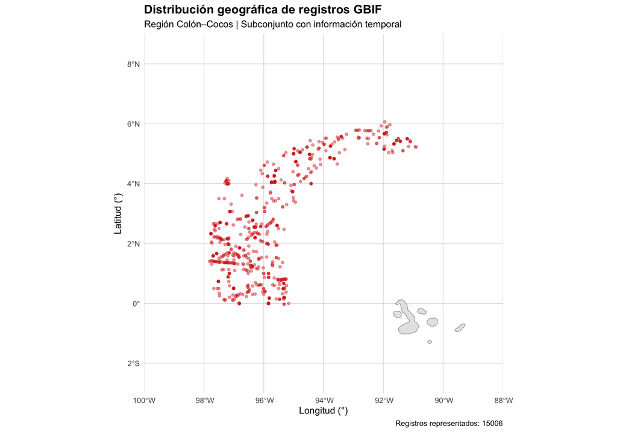

```r
mundo <- rnaturalearth::ne_countries(scale = "medium", returnclass = "sf")

ggplot() +
  geom_sf(data = mundo, fill = "gray90", color = "gray55", linewidth = 0.25) +
  geom_point(data = datos_mapa,
             aes(x = longitud, y = latitud),
             color = "#D73027", alpha = 0.45, size = 1.2) +
  coord_sf(xlim = c(-100, -88), ylim = c(-3, 9), expand = FALSE) +
  labs(title = "Distribución geográfica de registros GBIF",
       subtitle = "Región Colón–Cocos | Subconjunto con información temporal",
       x = "Longitud (°)", y = "Latitud (°)",
       caption = paste("Registros representados:", nrow(datos_mapa))) +
  theme_minimal() +
  theme(plot.title = element_text(face = "bold", size = 14),
        panel.grid.major = element_line(color = "gray85", linewidth = 0.3))
```

**Limitaciones de interpretación.** Los puntos indican ocurrencias registradas, no individuos distintos ni densidades biológicas. La superposición de puntos puede ocultar registros coincidentes. Debe revisarse por separado la precisión espacial, la pertenencia al ámbito marino Colón–Cocos, los tipos de registro (incluidos fósiles) y la calidad taxonómica antes de usar estas cifras como estimaciones ecológicas.

## 8. Análisis del origen de los registros históricos

Se analizan los registros correspondientes a los años 1970, 1979 y 1991, con el objetivo de identificar los conjuntos de datos, instituciones publicadoras y tipos de evidencia que explican su elevada representación en GBIF.

**Código**

```r
# Seleccionar los tres años de interés desde la base original
datos_historicos <- datos_gbif %>%
  filter(year %in% c(1970, 1979, 1991))

# Total de registros por año
resumen_historico <- datos_historicos %>%
  count(year, name = "numero_registros") %>%
  arrange(desc(numero_registros))

print(resumen_historico, n = Inf)
```

```
# A tibble: 3 × 2
   year numero_registros
  <dbl>            <int>
1  1991             6027
2  1979             5564
3  1970             1716
```

### 8.1. Conjuntos de datos de procedencia

**Código**

```r
origen_datasets <- datos_historicos %>%
  group_by(year, datasetName, datasetKey) %>%
  summarise(
    numero_registros = n(),
    .groups = "drop"
  ) %>%
  arrange(year, desc(numero_registros))

print(origen_datasets, n = Inf)
```

```
# A tibble: 24 × 4
    year datasetName                                 datasetKey numero_registros
   <dbl> <chr>                                       <chr>                 <int>
 1  1970 <NA>                                        7fc3d896-…             1078
 2  1970 <NA>                                        8e8e6572-…              404
 3  1970 <NA>                                        8e8d00b0-…              207
 4  1970 <NA>                                        87220b2c-…               18
 5  1970 <NA>                                        73d15adc-…                3
 6  1970 <NA>                                        73d295f0-…                2
 7  1970 Mammal                                      f86a681d-…                1
 8  1970 Vascular plants                             d415c253-…                1
 9  1970 <NA>                                        743f5460-…                1
10  1970 <NA>                                        b6015b60-…                1
11  1979 <NA>                                        7fc3d896-…             3205
12  1979 <NA>                                        954c2e4e-…             1782
13  1979 <NA>                                        8ebaa7f4-…              310
14  1979 <NA>                                        8ebc11de-…              256
15  1979 Cnidarios, poliquetos, crustáceos (decápod… 7f915a0c-…                6
16  1979 <NA>                                        78dcfcbd-…                2
17  1979 LACM Vertebrates                            7a25f7aa-…                1
18  1979 <NA>                                        13fdfab7-…                1
19  1979 <NA>                                        6c032b27-…                1
20  1991 <NA>                                        cf9db3d8-…             3902
21  1991 <NA>                                        1de4d9a0-…             1229
22  1991 <NA>                                        8fed1f44-…              509
23  1991 <NA>                                        3314ccbd-…              355
24  1991 <NA>                                        dc5aa964-…               32
```

### 8.2. Instituciones y publicadores

**Código**

```r
origen_instituciones <- datos_historicos %>%
  group_by(year, publisher, institutionCode) %>%
  summarise(
    numero_registros = n(),
    .groups = "drop"
  ) %>%
  arrange(year, desc(numero_registros))

print(origen_instituciones, n = Inf)
```

```
# A tibble: 14 × 4
    year publisher                              institutionCode numero_registros
   <dbl> <chr>                                  <chr>                      <int>
 1  1970 Flanders Marine Institute              Pangaea                     1078
 2  1970 PANGAEA - Data Publisher for Earth & … Pangaea                      635
 3  1970 Canadian Museum of Nature              CMN                            1
 4  1970 Texas A&M University Biodiversity Res… TCWC                           1
 5  1970 The New York Botanical Garden          NY                             1
 6  1979 Flanders Marine Institute              Pangaea                     3205
 7  1979 PANGAEA - Data Publisher for Earth & … Pangaea                     2348
 8  1979 Comisión nacional para el conocimient… FC-UNAM                        6
 9  1979 Museum of Biological Diversity, The O… Ohio State Uni…                2
10  1979 Museum of Biological Diversity, The O… Cleveland Muse…                1
11  1979 Natural History Museum of Los Angeles… LACM                           1
12  1979 Natural Science Research Laboratory, … TTU                            1
13  1991 Flanders Marine Institute              Pangaea                     3902
14  1991 PANGAEA - Data Publisher for Earth & … Pangaea                     2125
```

### 8.3. Tipos de registros

**Código**

```r
tipos_historicos <- datos_historicos %>%
  count(year, basisOfRecord, name = "numero_registros") %>%
  group_by(year) %>%
  mutate(
    porcentaje = round(
      numero_registros / sum(numero_registros) * 100, 2
    )
  ) %>%
  ungroup() %>%
  arrange(year, desc(numero_registros))

print(tipos_historicos, n = Inf)
```

```
# A tibble: 8 × 4
   year basisOfRecord      numero_registros porcentaje
  <dbl> <chr>                         <int>      <dbl>
1  1970 OCCURRENCE                     1078      62.8
2  1970 HUMAN_OBSERVATION               635      37
3  1970 PRESERVED_SPECIMEN                3       0.17
4  1979 OCCURRENCE                     3205      57.6
5  1979 HUMAN_OBSERVATION              2348      42.2
6  1979 PRESERVED_SPECIMEN               11       0.2
7  1991 OCCURRENCE                     3902      64.7
8  1991 HUMAN_OBSERVATION              2125      35.3
```